# Lab 3

Due 27/6/2018

GROUP Number: 13  
Name of 1st group member: Ran Stern  
Email of 1st group member: ran.stern@mail.huji.ac.il  
Name of 2st group member: Adi Ziv Email of 2st group member: AdiZiv1@mail.huji.ac.il

**Instructions:**  
1. Please rename your group lab_3 rmd file as - `Lab3_group#.rmd`.  
** The # should be replaced by your group number.  
2. Fill in your code in the relevant code execution boxes.  
3. Please avoid plagiarism - do not share your answers with other groups.  
4. Use the encryption guide (see moodle) to encrypt your final rmd file and name it `Lab3_group#_crypt`  
5. Upload the encrypted file to the following link:  
** `https://github.com/DataScienceHU/DataAnalysisR/tree/master/Lab3/Lab3_submission/`

# Lab 3

**Monte Carlo method is a useful tool for transforming problems of probabilistic nature into deterministic computations using the law of large numbers.**

1. Itegration:
1. What is the functional of `x` in the function below? (i.e., how is `g(x)` distributed?)
   $$\int_{-2}^{12}\frac{1}{10\sqrt{2\pi}}e^{-\frac{(x-1)^2)}{2\times10^2}}dx$$
2. Calculate the integral above using Monte Carlo simulation. Monte Carlo simulations are done by generating samples of $g(x)$ and then estimating $E[g(x)]$ from our simulations output. Use 100,000 simulations to estimate the integral.

```r
## Writing the FUNCTION
f <- function(x) { (1/(10*sqrt(2*pi))) * (exp(((-(x-1)^2))/(2*10^2))) }

##Iterations
mc.integral = function(FUN, n.iter = 100000, interval){
  x = runif(n.iter, interval[1], interval[2])
  y = FUN(x)
  mean(y)*(interval[2] - interval[1])
}



integ = mc.integral(f,100000, interval = c(-2, 12))
print(integ)
```

```
## [1] 0.4822412
```

3. Find out the true integral value.

```r
##integrate FUNCTION
f <- function(x) { (1/(10*sqrt(2*pi))) * (exp(((-(x-1)^2))/(2*10^2))) }
true <- integrate(f, -2, 12)
true
```

```
## 0.4822454 with absolute error < 5.4e-15
```

4. Create a plot that demonstrates the Law of Large Numbers using the itegration simulation and the true integral value.

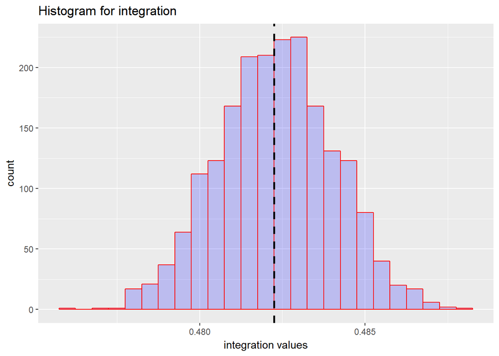

```r
integran<-data.frame(x=vector(length = 2000))
for (i in 1:2000) {
integran$x[i] <- mc.integral(f,2000, interval = c(-2, 12))
}

qplot(integran,
      geom="histogram",
      binwidth = 0.0005,
      main = "Histogram for integration",
      xlab = "integration values",
      fill=I("blue"),
      col=I("red"),
      alpha=I(.2))+
      geom_vline(aes(xintercept = true$value),linetype='dashed', size=1)
```

2. The area of the circle is $A_{circle} = \pi r^2$. The area of a square containing this circle is $A_{square} = 4r^2$. We can use this information to estimate $\pi$ , the ratio of a circle’s circumference to its diameter.
1. What is the ratio of the area of the circle to the area of the square?
2. How can we use this information to estimate $\pi$?
3. Write a Monte Carlo simulation that achieves exactly that.

```r
simulations <- 10000 # number of simulations
perimeter <- 1

# randomly generate a point and check if it is in circle
f_point_in_circle <- function(perimeter=1){
  x <- runif(n=1, min=-perimeter, max=perimeter)
  y <- runif(n=1, min=-perimeter, max=perimeter)
  return(list(x=x,
              y=y,
              in_circle=x^2 + y^2 <= perimeter^2))
}

# Monte Carlo simulations
set.seed(123)
pi_df <- data.frame(x=rep(NA, simulations),
                    y=rep(NA, simulations),
                    in_circle=rep(NA, simulations))
for (i in seq(simulations)){
  my_simulation <- f_point_in_circle()
  pi_df$in_circle[i] <- my_simulation$in_circle
  pi_df$x[i] <- my_simulation$x
  pi_df$y[i] <- my_simulation$y
}

my_pi <- 4 * sum(pi_df$in_circle) / nrow(pi_df)
```

4. Plot the points that fall inside the circle in one color and outside in another, showing Monte Carlo simulation on the circle and square.

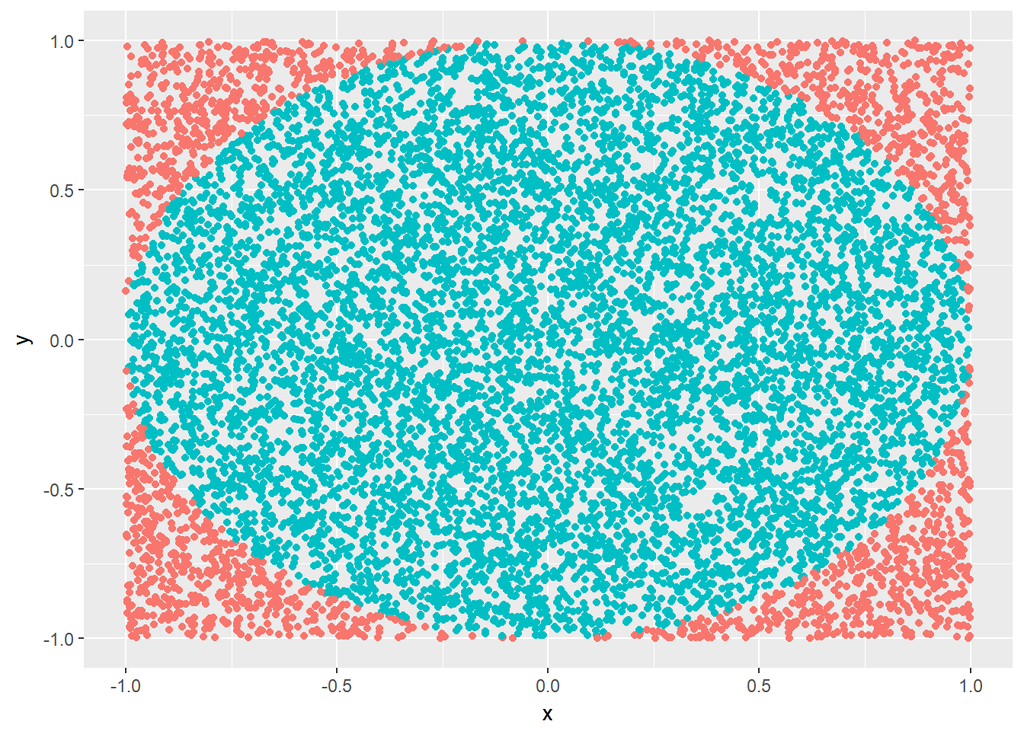

```r
ggplot(pi_df, aes(x=x, y=y, color=as.factor(in_circle))) +
  geom_point() +
  theme(legend.position='none')
```

3. [Value at risk or](https://en.wikipedia.org/wiki/Value_at_risk) is a measure of the risk of loss for investments and is widely used by financial institutions. Value at Risk estimates how much of a stock/portfolio/investment might lose or gain (with a given probability), given normal/abnormal market conditions and assumptions, during a fixed time.
   For this example our stockastic process of choice is the popular [Geometric Brownian motion](https://en.wikipedia.org/wiki/Geometric_Brownian_motion):
   $$S_{t+1} = S_t \times(1 +\mu \Delta_t + \sigma\epsilon \sqrt(\Delta_t))$$
   where $S_t$ is price in time $t$, $\mu$ is our drift, $\Delta_t$ means one period, $\sigma$ is our volatility and $\epsilon$ is a random uniform number between 0 and 1.
1. Using the package `quantmod::getSymbols`, load daily data of the NASDAQ (date & adjusted price) starting from `2010-01-01`.

```r
nasdaq <- new.env()
nasdaq <- getSymbols("^IXIC", from = "2010-01-01", auto.assign = F)
```

[output not shown]

[output not shown]

```r
#or
#quantmod::getSymbols("^IXIC", from = "2010-01-01")
#nasdaq = IXIC
```

2. Write a function `f.stock.return` that accepts `stock_price`,`n_periods`, `stock_mu`,`stock_sigma` and outputs the Brownian Motion prices vector (including the initial starting price) along the periods. Use the following:
   $$(1 +\mu \Delta_t + \sigma\epsilon \sqrt(\Delta_t)) = (1 + qnorm(epsilon, stock\_mu \times delta\_t, stock\_sigma \times sqrt(delta\_t)))$$
   Define delta_t as $1/n$. Once done, test your function using `f.stock.return(7000,20,0.05,0.2)`.

```r
f.stock.return <- function(stock_price,n_periods,stock_mu, stock_sigma){
  stock_prices<-vector(length =n_periods+1 )
  stock_prices[1]=stock_price
  n=n_periods
  delta_t <- 1/n # one period
  epsilon <- runif(n=1, min=0, max=1) # random generated number
  for (i in 2:(n+1)){
    # calculate stock price (using quantile function of normal distribution)
    stock_prices[i] <- stock_prices[i-1] * (1 + qnorm(epsilon,
                                            stock_mu * delta_t,
                                            stock_sigma* sqrt(delta_t)))
  }
  return(stock_prices)
}

f.stock.return(stock_price = 7000,n_periods = 20,stock_mu = 0.05,stock_sigma = 0.2)
```

```
##  [1]  7000.000  7307.685  7628.894  7964.222  8314.289  8679.743  9061.261
##  [8]  9459.549  9875.343 10309.413 10762.563 11235.631 11729.493 12245.063
## [15] 12783.294 13345.184 13931.771 14544.142 15183.429 15850.816 16547.538
```

3. Plot the prices along their respective dates (from beginning of `2015-01-01`). Seperately, calculate the mean and standard deviation of the nasdaq prices from `2016-02-01` and forward - you will use this information as the model parameters.

[figure not shown]

```r
##Calculating standard deviation nasdaq prices from `2016-02-01':
nasdaq_c <- new.env()
nasdaq_c <- getSymbols("^IXIC", from = "2016-02-01", auto.assign = F)
NDX_3 <- as.data.frame(nasdaq_c)
NDX_SD <- sd(NDX_3$IXIC.Adjusted/100)
NDX_MEAN <- mean(NDX_3$IXIC.Adjusted)

dates <- as.Date(index(nasdaq),format="%Y%m%d")
x <- (dates)
nasdaq_c1 <- data.frame(x,nasdaq[,-(1:5)])

ggplot(subset(nasdaq_c1,nasdaq_c1$x>="2015-01-01"),aes(x = x,y =IXIC.Adjusted ))+
  geom_line()+
  labs(title = "Nasdaq Prices Along their Respective Dates",
      subtitle = "from beginning of `2015-01-01`",
      caption=paste("mean of the nasdaq prices from 2016-02-01 : ",round(NDX_MEAN,2),",\n standard deviation of the nasdaq prices from 2016-02-01 : ",round(NDX_SD,2)),
      x = "Dates", y = "Price")+
  theme_economist()
```

4. Using your function and the mean and sd you calculated in (c), simulate 10 different scenarios starting at the beginning of May 2018, going 21 days into May. Plot these simulated data together with the real prices.

```r
NDX_MEAN = mean(as.numeric(nasdaq_c$IXIC.Adjusted[-1]) - as.numeric(nasdaq_c$IXIC.Adjusted[-605]))/100
NDX_SD = sd(as.numeric(nasdaq_c$IXIC.Adjusted[-1]) - as.numeric(nasdaq_c$IXIC.Adjusted[-605]))/100

#another way to wotk withdates
#NDX_MEAN = mean(as.numeric(nasdaq$IXIC.Adjusted["2016-02-01/"][-1]) - as.numeric(nasdaq$IXIC.Adjusted["2016-02-01/"][-605]))/100
#NDX_SD = sd(as.numeric(nasdaq$IXIC.Adjusted["2016-02-01/"][-1]) - as.numeric(nasdaq$IXIC.Adjusted["2016-02-01/"][-605]))/100

set.seed(01072018)
nasdaq_d <- new.env()
nasdaq_d <- getSymbols("^IXIC", from = "2018-05-01", to = "2018-05-31",auto.assign = F)
IXIC.df <- data.frame(index(nasdaq_d),coredata(nasdaq_d),stringsAsFactors=F)
IXIC.df<-data.frame(IXIC.df$index.nasdaq_d.,IXIC.df$IXIC.Adjusted)

for(i in 1:10){
  simulate = f.stock.return(stock_price = IXIC.df$IXIC.df.IXIC.Adjusted[1],
                            n_periods = 20,
                            stock_mu = NDX_MEAN,
                            stock_sigma = NDX_SD)
  IXIC.df$simulate =simulate
  names(IXIC.df)<-c(names(IXIC.df)[-length(names(IXIC.df))],paste("simulate ",i))
}
data_d<-melt(data = IXIC.df[,-1])
```

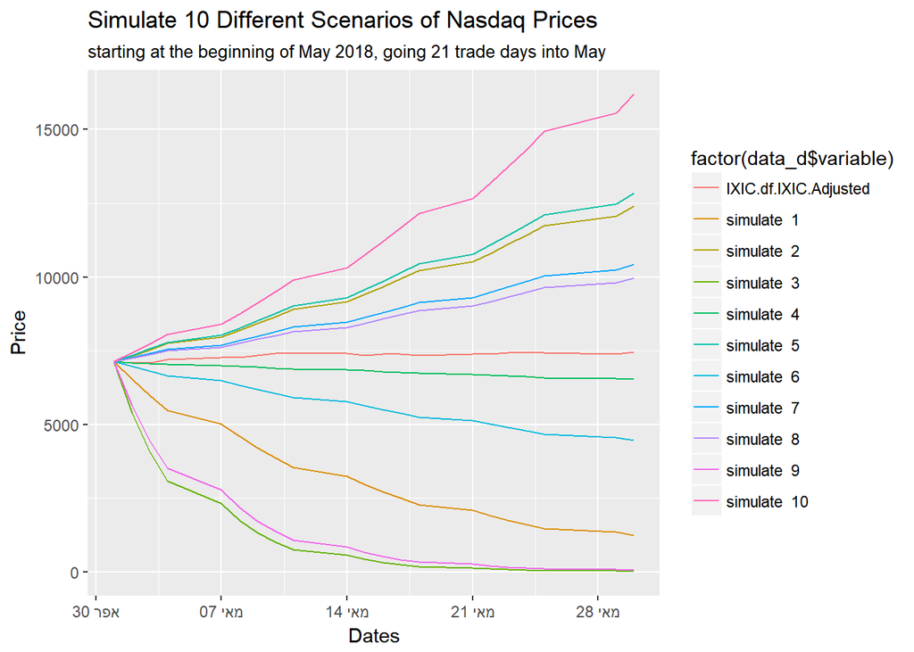

```r
data_d<-data.frame(rep(IXIC.df$IXIC.df.index.nasdaq_d.,11),data_d)

ggplot(data_d,aes(x =data_d$rep.IXIC.df.IXIC.df.index.nasdaq_d...11.,y =data_d$value,color=factor(data_d$variable)))+
  geom_line()+
  ylim(0,max(data_d$value))+
  labs(title = "Simulate 10 Different Scenarios of Nasdaq Prices",
      subtitle = "starting at the beginning of May 2018, going 21 trade days into May",
      x = "Dates", y = "Price")
```

5. Using Monte Carlo and the function you created, simulate 10000 different stock runs (keeping only the last price in each run - should be index 22), and use `quantile()` to explain the Value at Risk of our model.

```r
last_price = vector()
for(i in 1:10000){
  last_price[i] = f.stock.return(stock_price = IXIC.df$IXIC.df.IXIC.Adjusted[1],
                            n_periods = 20,
                            stock_mu = NDX_MEAN,
                            stock_sigma = NDX_SD)[21]
}
quantile(last_price)
```

```
##           0%          25%          50%          75%         100%
## 1.676732e-03 1.521034e+03 7.652798e+03 3.425803e+04 8.077949e+06
```

6. What are the odds that the NASDAQ price will drop below $5000?

```r
sum(last_price<5000)/length(last_price)
```

```
## [1] 0.4264
```

4. [Assessment 5 Revisit](https://moodle2.cs.huji.ac.il/nu17/mod/resource/view.php?id=246918):  
   First, read the parsing_gap_minder_messy.txt file into r using `readLines` and print a few rows.

```r
data <- readLines("C:/Ran/R/Advance Course/Lab3/parsing_gap_minder_messy.txt")
#data <- readLines("C:/Users/Alpha/Documents/university/yearc/simesterB/DataAnalysiswithR/assessments/parsing_gap_minder_messy.txt" )
head(data)
```

```
## [1] "Afghanistan19528425333Asia28.80100G779.4453145"
## [2] "Afghanistan19579240934Asia30.33200G820.8530296"
## [3] "Afghanistan196210267083Asia31.99700G853.10071"
## [4] "Afghanistan196711537966Asia34.02000G836.1971382"
## [5] "Afghanistan197213079460Asia36.08800G739.9811058"
## [6] "Afghanistan197714880372Asia38.43800G786.11336"
```

1. We want to make sure that every line starts with a country name.  
   Use `str_detect` with the appropriate regex to test that every line of the data starts with a capital letter exactly once (no other capital letters follow it).

```r
sum_match <- sum(str_detect(pattern = "[A-Z]", string = data)==TRUE, na.rm = TRUE)
stopifnot(sum_match==length(data))
```

2. Now let’s match against the continent. Here are the possible continents: `Africa,Eruope,Americas,Asia,Oceania`. Use `str_detect` with the appropriate regex to test that every line has at least one of these continents.

```r
sum_match <- sum(str_detect(pattern = "(Africa|Europe|Americas|Oceania|Asia)", string = data)==TRUE, na.rm = TRUE)
stopifnot(sum_match==length(data))
```

3. Create a regex that matches complety to our data. Hint: the life expectancy and gdp can be whole numbers (instead of fractions). In addition, consider some odd character in the country name. The `*` regex character is useful for that…

```r
matches_complety = str_extract(data, "^[[A-Z][a-z]*+[\\'|\\,|\\-\\.]?]*+\\d*+[[Africa|Europe|Americas|Asia|Oceania]]*+\\d*+\\.{1}+\\d*+G{1}+\\d*+\\.*+\\d*")
stopifnot(all(matches_complety==data))
```